# Title of the Talk

29 January 2026

## Introduction

## Beamer Presentation Template

This template has the same features as others in the **memoiR** package except for multi-language support (no `lang` item in the header).

See the code of the following slides for some specific code of slides.

## Advanced code

## Slide with Incremental Bullets

Incremental bullets start with `> -` instead of `-`:

- Bullet 1
- A reference: Xie (2016).
- Bullet 3

## Slide with R Output

R code chunks are displayed as follows:

```r
head(cars)
```

```
##   speed dist
## 1     4    2
## 2     4   10
## 3     7    4
## 4     7   22
## 5     8   16
## 6     9   10
```

## Slide with a Centered Plot

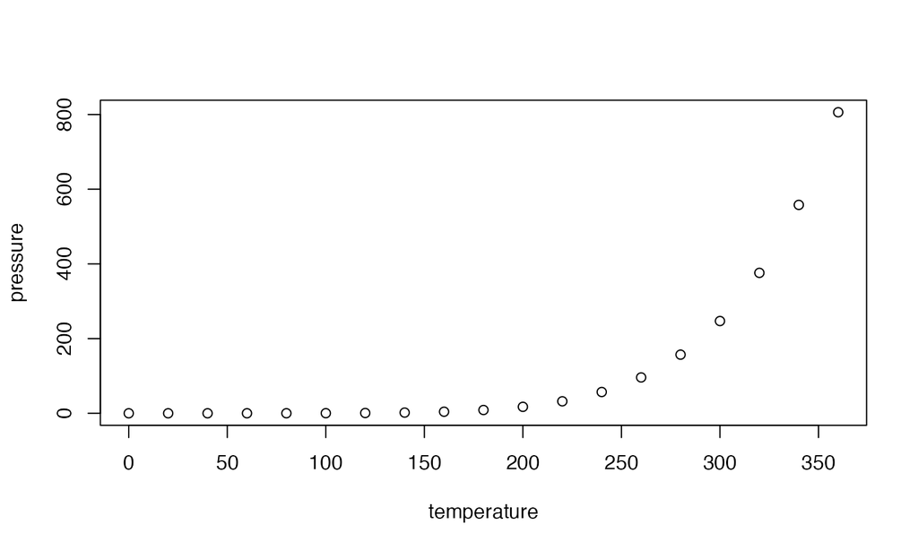

## Two Column Layout

This slide has two columns.

In Beamer, each column in between `\begincol` and `\endcol`.

In HTML, the `{.columns-2}` option is added to the slide title and `<p class="forceBreak"></p>` allows forcing column break.

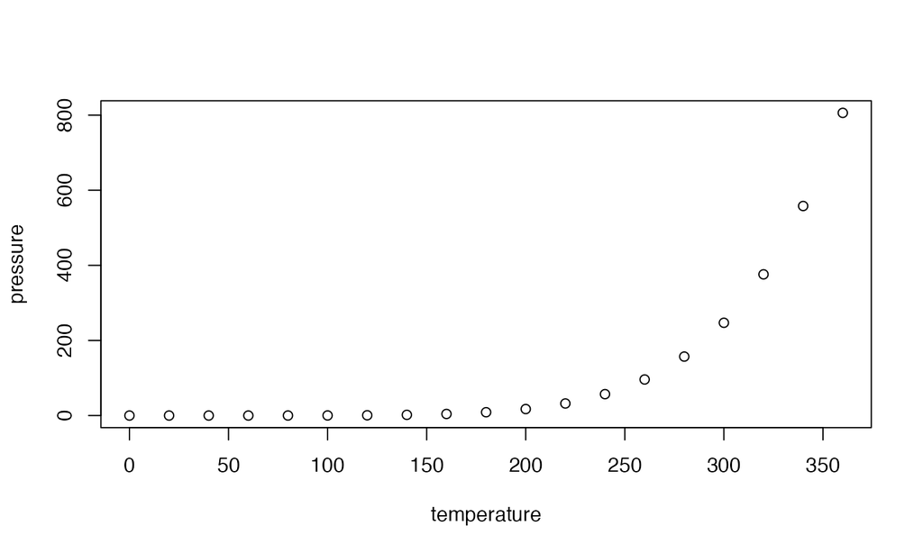

## Documentation

See [R Markdown: The Definitive Guide](https://bookdown.org/yihui/rmarkdown/ioslides-presentation.html) for full documentation about HTML slides.

Note:

- `{.flexbox .vcenter}` to center the HTML slide with plot.
- `out.width='90%'` to reduce the size of the plot in the Two Column Layout slide.

## References

Xie, Yihui. 2016. *Bookdown: Authoring Books and Technical Documents with R Markdown*. Boca Raton, Florida: Chapman; Hall/CRC. https://github.com/rstudio/bookdown.